# AppSec is Eating Security: 2021 Edition

source for the ethernet speeds and interpacket gaps: https://en.wikipedia.org/wiki/Interpacket_gap

9.6 µs for 10 Mbit/s Ethernet, 0.96 µs for 100 Mbit/s (Fast) Ethernet, 96 ns for Gigabit Ethernet, 38.4 ns for 2.5 Gigabit Ethernet, 19.2 ns for 5 Gigabit Ethernet, 9.6 ns for 10 Gigabit Ethernet, 3.84 ns for 25 Gigabit Ethernet, 2.4 ns for 40 Gigabit Ethernet, 1.92 ns for 50 Gigabit Ethernet, 0.96 ns for 100 Gigabit Ethernet, 0.48 ns for 200 Gigabit Ethernet, and 0.24 ns for 400 Gigabit Ethernet.[1]

interpacket_gaps <- c(9.6 µs, 0.96 µs, 96 ns, 38.4 ns, 19.2 ns, 9.6 ns, 3.84 ns, 2.4 ns, 1.92 ns, 0.96 ns, 0.48 ns, 0.24 ns) ethernet_speed <- c(10 Mbit/s, 100 Mbit/s, 1 Gigabit, 2.5 Gigabit, 5 Gigabit, 10 Gigabit, 25 Gigabit, 40 Gigabit, 50 Gigabit, 100 Gigabit, 200 Gigabit, 400 Gigabit)

define inputs assuming that 1 Gigabit = 1 Gbit/s

```r
interpacket_gaps_ns <- c(9600, 960, 96, 38.4, 19.2, 9.6, 3.84, 2.4, 1.92, 0.96, 0.48, 0.24)
ethernet_speed_gbps <- c(0.01, 0.1, 1, 2.5, 5, 10, 25, 40, 50, 100, 200, 400)
data <- tibble(interpacket_gaps_ns, ethernet_speed_gbps)
```

FOR THE PLOT: the interpacket gap as the response variable (y), and the ethernet speed as the predictor variable (x) because that is what makes the most sense

building a model

```r
y <- data$ethernet_speed_gbps
x <- data$interpacket_gaps_ns
model <- lm(log(y) ~ log(x))
summary(model)
```

```
##
## Call:
## lm(formula = log(y) ~ log(x))
##
## Residuals:
##        Min         1Q     Median         3Q        Max
## -1.507e-15 -5.642e-16  1.329e-16  3.311e-16  2.163e-15
##
## Coefficients:
##               Estimate Std. Error    t value Pr(>|t|)
## (Intercept)  4.564e+00  3.740e-16  1.220e+16   <2e-16 ***
## log(x)      -1.000e+00  9.531e-17 -1.049e+16   <2e-16 ***
## ---
## Signif. codes:  0 '***' 0.001 '**' 0.01 '*' 0.05 '.' 0.1 ' ' 1
##
## Residual standard error: 9.956e-16 on 10 degrees of freedom
## Multiple R-squared:      1,  Adjusted R-squared:      1
## F-statistic: 1.101e+32 on 1 and 10 DF,  p-value: < 2.2e-16
```

speed of cycles to access RAM, L3 cache, L2 cache and L1 cache intel i7-6700 processor using DDR4-2400 RAM source: Mundhenke, M. 2019. Spectre and Cloud: An evaluation of threats in shared computation environments.

```r
gaps <- data.frame(x = c(61.5, 10.5, 3.5, 1))
```

using the model to predict the ethernet speeds for the gaps:

```r
speeds <- data.frame(predict(model, newdata = gaps))
```

the model returned log values of y putting it all together

```r
intel <-cbind(gaps, speeds) %>%
  rename(interpacket_gaps_ns = x,
         log_ethernet_speed_gbps = predict.model..newdata...gaps.) %>%
  mutate(
         ethernet_speed_gbps = exp(log_ethernet_speed_gbps)
         )
```

extracting the values for plotting

```r
RAM_gap <- intel[1,1]
L3_gap <- intel[2,1]
L2_gap <- intel[3,1]
L1_gap <- intel[4,1]

RAM_speed <- intel[1,3]
L3_speed <- intel[2,3]
L2_speed <- intel[3,3]
L1_speed <- intel[4,3]
```

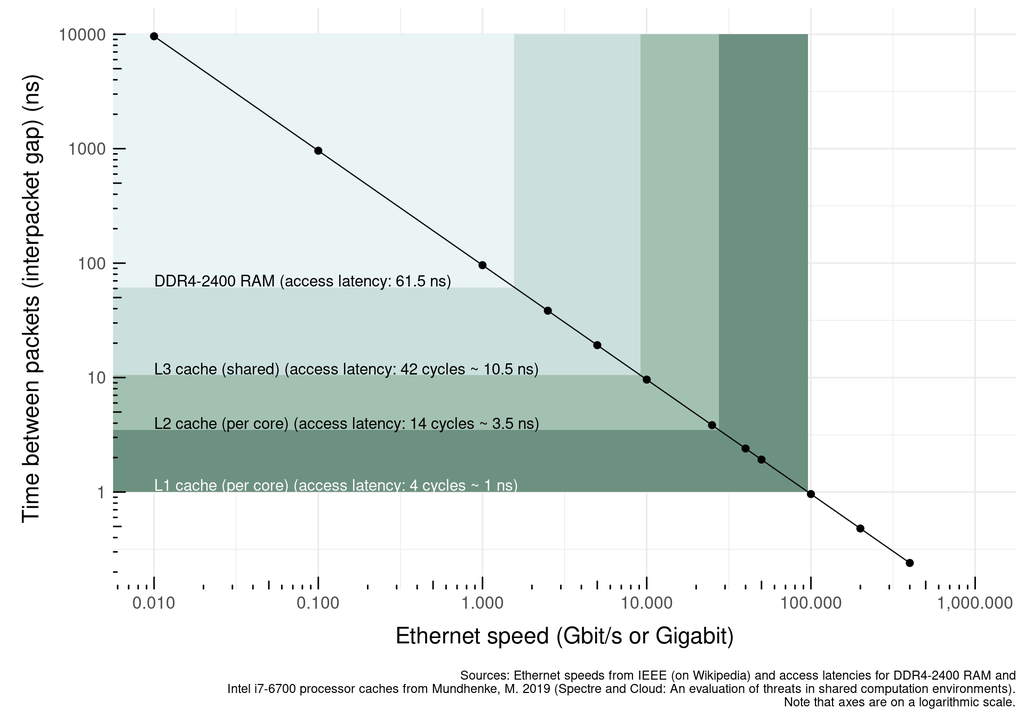

```r
data %>%
  ggplot(aes(x = ethernet_speed_gbps, y = interpacket_gaps_ns)) +
  geom_rect(mapping=aes(xmin=0, xmax=L1_speed, ymin=L1_gap, ymax=10000), fill = "#6b9080", alpha=0.3) +
  geom_rect(mapping=aes(xmin=0, xmax=L2_speed, ymin=L2_gap, ymax=10000), fill = "#a4c3b2", alpha=0.3) +
  geom_rect(mapping=aes(xmin=0, xmax=L3_speed, ymin=L3_gap, ymax=10000), fill = "#cce3de", alpha=0.3) +
  geom_rect(mapping=aes(xmin=0, xmax=RAM_speed, ymin=RAM_gap, ymax=10000), fill = "#eaf4f4", alpha=0.3) +
  geom_point(size = 2) +
  geom_smooth(color = "black", size = 0.4) +
  scale_x_continuous(
    trans = "log10",
    labels = comma,
    limits = c(NA, 1000),
    breaks = c(0, 0.01, 0.1, 1, 10, 100, 1000),
    ) +
  annotation_logticks(base = 10) +
  scale_y_continuous(trans = "log10") +
  labs(
    x = "Ethernet speed (Gbit/s or Gigabit)",
    y = "Time between packets (interpacket gap) (ns)",
    caption = "Sources: Ethernet speeds from IEEE (on Wikipedia) and access latencies for DDR4-2400 RAM and\n Intel i7-6700 processor caches from Mundhenke, M. 2019 (Spectre and Cloud: An evaluation of threats in shared computation environments).\n Note that axes are on a logarithmic scale."
  ) +
  theme_minimal() +
  theme(
    plot.title = element_text(size=18, face="bold", margin=margin(20,0,20,0), hjust = 0.5, vjust = 0),
    axis.title.x = element_text(size=16, margin=margin(10,0,10,0)),
    axis.title.y = element_text(size=16, margin=margin(0,10,0,10)),
    axis.text.x = element_text(size=12),
    axis.text.y = element_text(size=12),
    legend.title = element_text(size = 14),
    legend.text = element_text(size = 12)
  ) +
  annotate("text", x=0.01, y=70, label= "DDR4-2400 RAM (access latency: 61.5 ns)", hjust = 0) +
  annotate("text", x=0.01, y=12, label= "L3 cache (shared) (access latency: 42 cycles ~ 10.5 ns)", hjust = 0) +
  annotate("text", x=0.01, y=4, label= "L2 cache (per core) (access latency: 14 cycles ~ 3.5 ns)", hjust = 0) +
  annotate("text", x=0.01, y=1.15, color = "#fffafa", label= "L1 cache (per core) (access latency: 4 cycles ~ 1 ns)", hjust = 0)
```